### I started analysis by comparing predicted Swine flu cases and deaths in 2009-2010 in different continents

[figure not shown]

### Next I looked for countries to check which country have highest cases and deaths due to swine flu

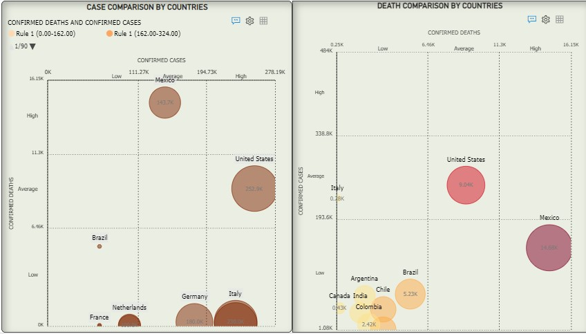

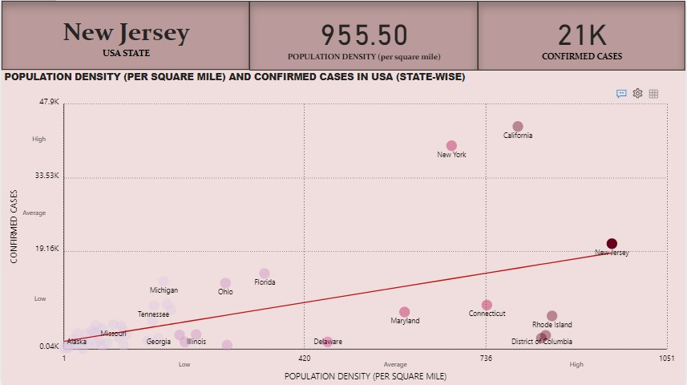

USA state with less population density had lower number of cases comparitively

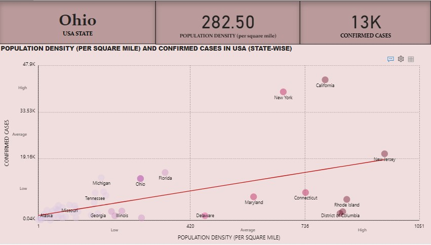

Mexico states with highest population density had highest number of cases

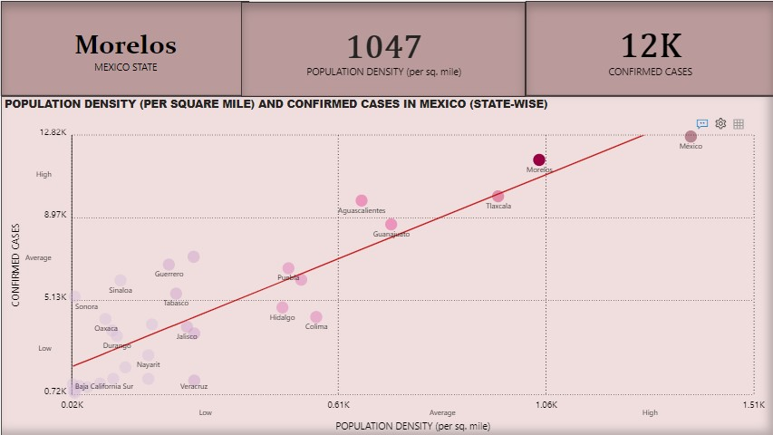

Mexico states with lower population density had lower number of cases comparatively

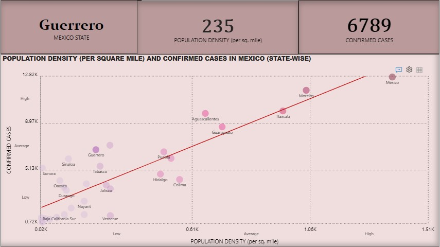

### Next I analyzed which age group was most affected and least affected by swine flu in USA and Mexico

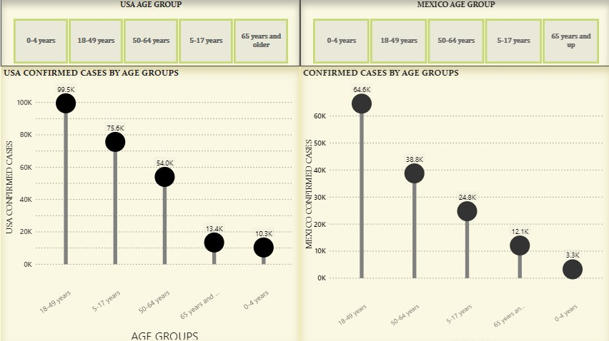

### Since swine was the main factor in spread of swine flu , so I analyzed trend of pork consumption(in thousand tons) from year 2008 to 2011, in countries which faced more fatalities and check if pork consumption actually dropped or not

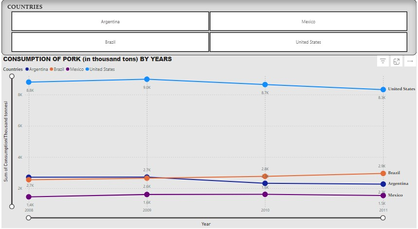

### Close look at pork consumption trend of USA from 2008 to 2011

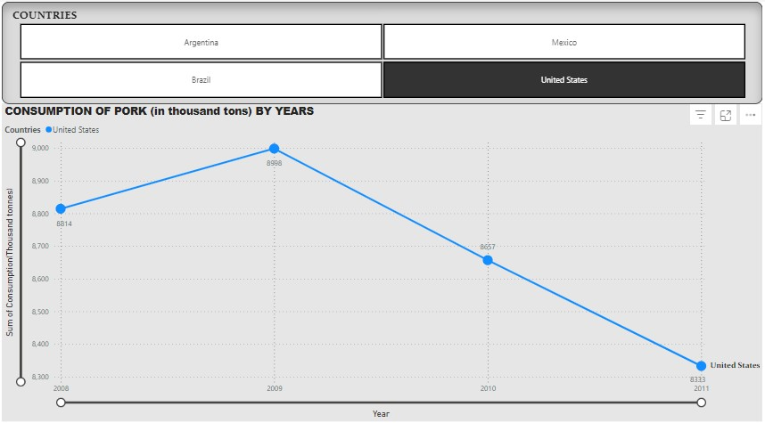

### Close look at pork consumption trend of Argentina from 2008 to 2011

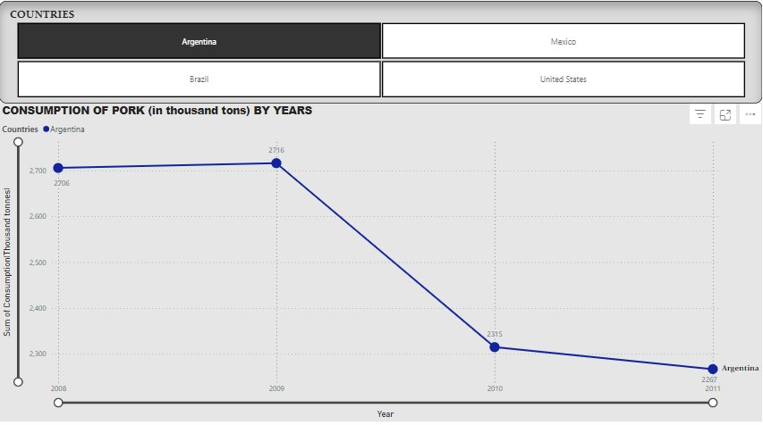